# Social Science Math Camp

Northwestern University

## Agenda

- Who are we?
- What is math camp?
- Who are you?
- What are we going to cover?
- Getting in the mindset

# Who are we?

## Co-instructors

**Artur Baranov**

PhD Student in Political Science  
artur.baranov@u.northwestern.edu

**Gustavo Diaz**

Assistant Professor of Instruction in Political Science  
gustavo.diaz@northwestern.edu

**Ronaldo Monasterio**

PhD Student in Sociology  
RonaldoMonasterio2028@u.northwestern.edu

# What is math camp?

## Math camp

- A (re)introduction to math topics necessary for the quantitative methods sequence

Goals:

- Get to know you and meet your methods training needs/goals
- Get to know your colleagues

## Math camp

- A (re)introduction to math topics necessary for the quantitative methods sequence

Why a *math camp*?

- Can always use more methods training
- More of a *methods* camp

## Who are you?

- Name
- Pronouns
- Where you are from
- Discipline + intended subfield/research area
- A hobby or interesting fact about yourself

## What are we going to cover?

| Week | Date | Morning | Afternoon |
| --- | --- | --- | --- |
| 1 | Wednesday, September 9 | Introduction | R and RStudio |
| 1 | Thursday, September 10 | Notation, sets, functions | Tidyverse I |
| 1 | Friday, September 11 | Matrices | Tidyverse II |
| 2 | Monday, September 14 | Calculus I | Sampling and simulation |
| 2 | Tuesday, September 15 | Calculus II | Markdown I |
| 2 | Wednesday, September 16 | Markdown II | NO MEETING |
| 2 | Thursday, September 17 | GitHub | NO MEETING |
| 2 | Friday, September 18 | Review | NO MEETING |

## Daily schedule

- **Breakfast** (9:00 - 9:30AM)
- **Morning:** Math (9:30AM - noon)
- **Lunch:** Meet faculty, students (noon - 1PM)
- **Break** (1 - 1:30PM)
- **Afternoon:** R programming (1:30 - 4PM)

[figure not shown]

See [gustavodiaz.org/NUmathcamp](https://gustavodiaz.org/NUmathcamp/) for content

## Learning goals

- Make you feel very stressed about things you are supposed to already know
- Me saying “I told you this was important” in five years
- Confront your fears about math early on
- So that you can do the cool things with confidence
- (The fear never goes away, but you learn to live with it)

## Expectations

- You are not being evaluated
- No need to take extensive notes
- Bring a laptop
- Engage
- Get things wrong
- Ask
- Interrupt if you need to

## Some notes

- Class is not graded, but you can get credit for attending (POLI_SCI 490)
- Content is cumulative (now and forever)
- Everyone comes in with different experiences and background. This is a feature, not a bug

## Expectations beyond math camp

- Read the material, learn to be strategic about it, come up with things to discuss
- People around you are colleagues, not competition. Treat everyone with respect (including yourself)
- Nobody knows what is going on, most people will help you figure things out
- There is life beyond grad school

# Questions?

Schedule a meeting if you want to chat: [cal.com/gustavodiaz](https://cal.com/gustavodiaz/)

[figure not shown]

# Break

# Getting in the mindset

## Why do I need mathcamp?

You are being trained to become a producer of **scientific knowledge**

**Science:** Knowledge generation through falsification

**Falsification:** Trying to prove *ourselves* wrong

## Scientific method

1. Puzzle/question
2. Theory/model
3. Hypothesis/implications
4. Observation/testing
5. Conclusion/evaluation

Your job will be to become good at *proposing* and *testing* **theories**

## What is a theory?

## What is a theory?

### ¯\*(ツ)*/¯

## What is a theory?

### ¯\*(ツ)*/¯

I have no idea

## What is a theory?

### ¯\*(ツ)*/¯

I have no idea

My *theory* is that no one really knows

## What is a theory?

### ¯\*(ツ)*/¯

I have no idea

My *theory* is that no one really knows

so they make it complicated

## What is a theory?

### ¯\*(ツ)*/¯

I have no idea

My *theory* is that no one really knows

so they make it complicated

and that’s why you need a PhD to do it well

## But it sure is important!

Most common reasons why a peer-reviewed journal rejects an article:

1. Having no theory
2. Weak theory
3. Insufficient theoretical innovation

If you ask me, theory is **logical explanation** or **informed speculation**

(but I am not the right person to ask)

## The important part

Sounds like splitting hairs, but there is a good reason for this

## Example

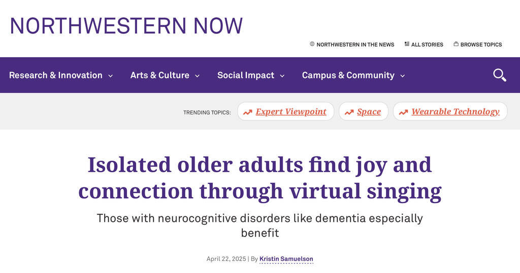

https://news.northwestern.edu/stories/2025/04/virtual-singing-brings-connection-and-joy-to-isolated-older-adults-study-finds/

## Details

> In collaboration with Illinois-based Sounds Good Choir, the study assessed the feasibility of virtual group singing for adults over 55 — including those with neurocognitive disorders like dementia — during the COVID-19 pandemic when older adults were experiencing health declines due to isolation. It found virtual group singing can be an effective tool for promoting well-being and social connection during isolation.

https://doi.org/10.1177/13872877251333155

## Findings

> Participants in the group choir during the pandemic consistently described the activity as providing a sense of normalcy amid widespread disruption — a theme that emerged prominently and merits further investigation.

> This suggests that such interventions may help restore a feeling of normalcy, supporting psychological well-being and offering a means of reconnecting with a stable sense of self.

https://doi.org/10.1177/13872877251333155

## Breaking it apart

**Question:** Can singing help overcome isolation?

**Theory:** Choral singing is a therapeutic activity for individuals with neurological disorders

**Hypothesis:** Individuals who sing in a choir will report higher levels of well-being than those who do not

**Test:** Organize virtual group choir, ask survey questions in the end

**Conclusion:** “Isolated older adults find joy and connection through virtual singing”

## Limitations?

**Ideal study**

Observe person $i$’s well-being with and without singing, everything else constant

**Actual study**

- Adults 55 an older in Chicago
- Elected to participate
- Two teleconferencing programs
- 176 survey responses out of 695 participants

## Problem

Cannot observe the ideal counterfactual

Any test/evidence can only be **suggestive**

Connecting from narrow findings to broad theories requires **assumptions**

## Statistics

Is all about acknowledging this gap and making assumptions *explicit, systematic, and credible*

- **Math** is a tool that helps us translate across domains
- The difficulty lies mostly in embracing the *abstraction*
- Less so on notation, symbols, operations

## Frequently asked questions

Do I need mathcamp if…

- I already have training in quantitative methods?
- I plan to use qualitative methods only?
- I am in political theory?
- I want a teaching job?
- I am considering non-academic jobs?